# DATA 621 Homework 1

### 8-9. F1 Score

```r
f1.score <- function(tbl, actual, predicted, pos_value, neg_value){
  p <- precision(dt, actual='class', predicted='predicted',
                 pos_value, neg_value)
  s <- sensitivity(dt, actual='class', predicted='predicted',
                   pos_value, neg_value)
  return ((2*p*s)/(p+s))
}

(f1 <- f1.score(dt, actual='class', predicted='predicted',
                pos_value, neg_value))
```

```
## [1] 0.6067416
```

Both *Precision* and *Sensitivity* have a range from 0 to 1. Consider that if $a>0$ and $0<b<1$, then $ab<a$ (a fraction of any positive number will be smaller than the original number).

Then $Precision \times Sensitivity < Precision$ and $Precision \times Sensitivity < Sensitivity$.

Then $Precision \times Sensitivity+Precision \times Sensitivity < Precision + Sensitivity$, or

$2\times Precision \times Sensitivity < Precision + Sensitivity$.

The fraction of these two values will be lower than $1$. Also, since both values are positive, $F1\ score$ will be positive. If $Precision$ is zero, then $Sensitivity$ is zero and $F1\ Score$ is not defined. If $Precision$ is one and $Sensitivity$ is one, then $F1\ Score$ is one.

So we have $0<F\ Score\le1$.

### 10. ROC Function

The following function calculates the proper specificity and sensivity based on provided probability by iterating from 0 to 1 at 0.01 interval. It then computes the area under the curve by summing up all relevant rectangles. Plot and AUC are returned.

```r
manual.roc <- function(tbl, actual, prob, pos_value, neg_value) {
  tbl2 <- tbl[, c(actual, prob)]
  tbl2 <- cbind(tbl2, predicted = rep(0, nrow(tbl)))

  cutoff <- seq(0,1,0.01)
  sens <- rep(0,length(cutoff))
  spec <- rep(0,length(cutoff))
  for (i in 1:length(cutoff)) {
    tbl3 <- within(tbl2, predicted[prob>cutoff[i]] <- 1)
    sens[i] <- sensitivity(tbl3, actual='class',
                           predicted='predicted', pos_value, neg_value)
    spec[i] <- specificity(tbl3, actual='class',
                           predicted='predicted', pos_value, neg_value)
  }
  roc.values <- as.data.frame(cbind(cutoff, sens, spec))
  roc.values[,'spec'] <- 1 - roc.values[,'spec']

  # Prepare plot
  pl <- ggplot(arrange(roc.values, desc(cutoff)), aes(x=spec, y=sens)) +
    geom_step() +
    xlab("1-Specificity") + ylab("Sensitivity") +
    ggtitle("ROC Curve")

  # Find AUC
  auc <- roc.values %>%
    arrange(desc(cutoff)) %>%
    mutate(auc =  (spec-lag(spec))*sens) %>%
    replace(is.na(.),0) %>%
    summarize(sum(auc))

  return (list(plot=pl, AUC=auc))
}
```

Let us run the function and review plot and AUC value.

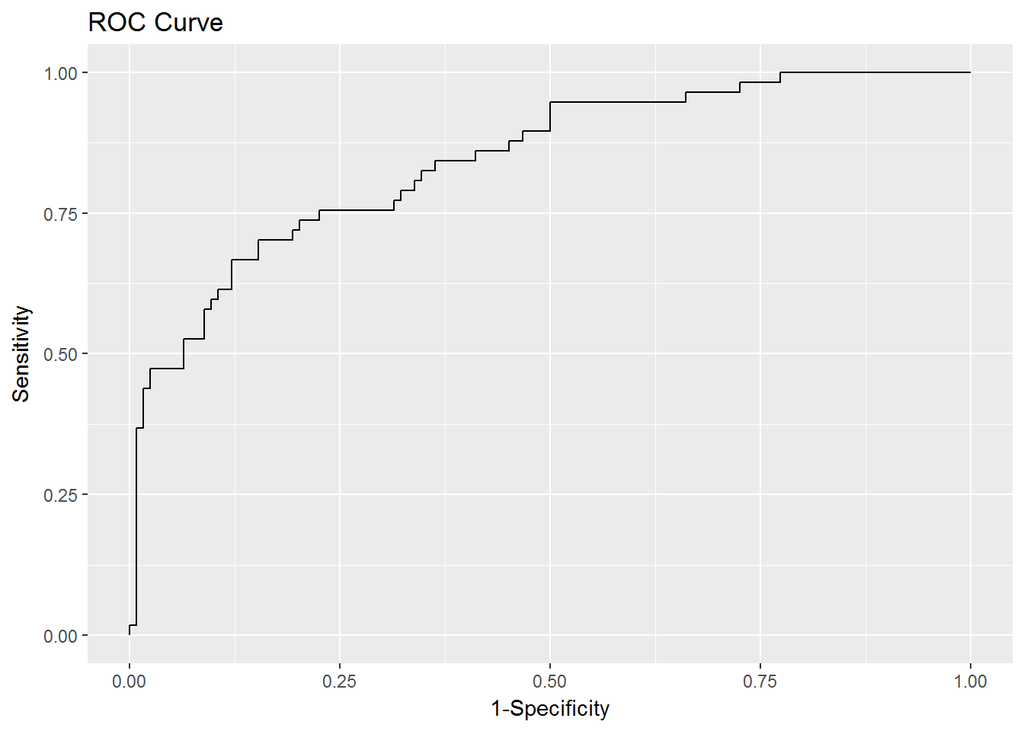

```r
mROC <- manual.roc(dt, 'class', 'prob', pos_value, neg_value)
mROC$plot
```

```r
mROC$AUC
```

```
##    sum(auc)
## 1 0.8539898
```

### 11. Classification Metrics

All metrics were provided as they were calculated. As we will see below using built-in functions makes life easier.

### 12. `caret` Package

`caret` package provides functions to calculate all of the values above and many more. For example, we can calculate sensitivity and specificity.

```r
caret::sensitivity(as.factor(dt$predicted), as.factor(dt$class), positive='1')
```

```
## [1] 0.4736842
```

```r
caret::specificity(as.factor(dt$predicted), as.factor(dt$class), negative='0')
```

```
## [1] 0.9596774
```

Even more encompassing function is `confusionMatrix`. It not only returns the actual confusion matrix, but other values including sensitivity and specificity.

```r
(cm <- confusionMatrix(dt$predicted, dt$class, positive='1'))
```

```
## Confusion Matrix and Statistics
##
##           Reference
## Prediction   0   1
##          0 119  30
##          1   5  27
##
##                Accuracy : 0.8066
##                  95% CI : (0.7415, 0.8615)
##     No Information Rate : 0.6851
##     P-Value [Acc > NIR] : 0.0001712
##
##                   Kappa : 0.4916
##  Mcnemar's Test P-Value : 4.976e-05
##
##             Sensitivity : 0.4737
##             Specificity : 0.9597
##          Pos Pred Value : 0.8438
##          Neg Pred Value : 0.7987
##              Prevalence : 0.3149
##          Detection Rate : 0.1492
##    Detection Prevalence : 0.1768
##       Balanced Accuracy : 0.7167
##
##        'Positive' Class : 1
##
```

Even these results do not display all possible values. Let us look specifically at `byClass` values returned by `confusionMatrix`.

```r
cm$byClass
```

```
##          Sensitivity          Specificity       Pos Pred Value
##            0.4736842            0.9596774            0.8437500
##       Neg Pred Value            Precision               Recall
##            0.7986577            0.8437500            0.4736842
##                   F1           Prevalence       Detection Rate
##            0.6067416            0.3149171            0.1491713
## Detection Prevalence    Balanced Accuracy
##            0.1767956            0.7166808
```

We can see F1 score, Precision and other values and with higher precision than the summary output above. All of the values match our calculations.

### 13. `pROC` Package

Let us try the `pROC` package.

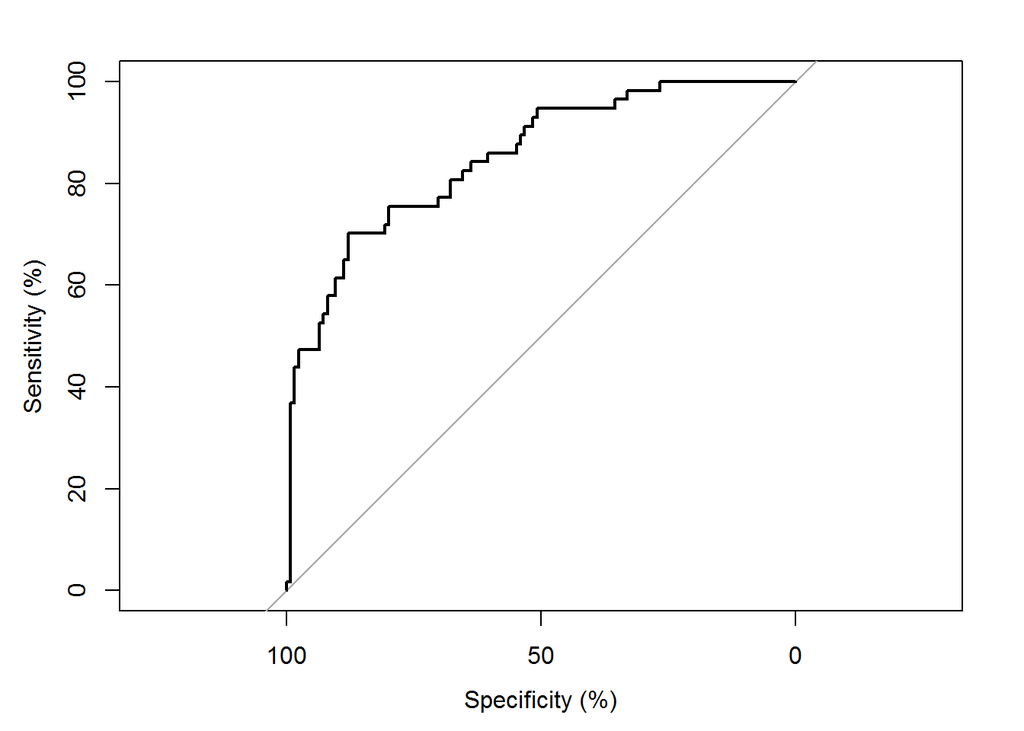

```
##
## Call:
## roc.default(response = dt$class, predictor = dt$prob, levels = c(0,     1), percent = TRUE, ci = TRUE, plot = TRUE)
##
## Data: dt$prob in 124 controls (dt$class 0) < 57 cases (dt$class 1).
## Area under the curve: 85.03%
## 95% CI: 79.05%-91.01% (DeLong)
```

```r
roc(dt$class, dt$prob, levels=c(0,1), percent=TRUE, plot=TRUE, ci=TRUE)
```

With one line of code we can get the ROC curve and several metrics. This plot looks very similar to our manual plot. We calculated AUC at 85.4% while `pROC` calculated it at 85.03%. The small difference is likely due slight discrepancy in how steps were calculated (it is also possible that the code leaves out a sliver somewhere).